# **EasyVisa_Predicting Visa Approval Outcomes Using Advanced Machine Learning Techniques**

# **Problem Statement**

## **Context**

Business communities in the United States are facing high demand for human resources, but one of the constant challenges is identifying and attracting the right talent, which is perhaps the most important element in remaining competitive. Companies in the United States look for hard-working, talented, and qualified individuals both locally as well as abroad.

The Immigration and Nationality Act (INA) of the US permits foreign workers to come to the United States to work on either a temporary or permanent basis. The act also protects US workers against adverse impacts on their wages or working conditions by ensuring US employers' compliance with statutory requirements when they hire foreign workers to fill workforce shortages. The immigration programs are administered by the Office of Foreign Labor Certification (OFLC).

OFLC processes job certification applications for employers seeking to bring foreign workers into the United States and grants certifications in those cases where employers can demonstrate that there are not sufficient US workers available to perform the work at wages that meet or exceed the wage paid for the occupation in the area of intended employment.

## **Objective**

In FY 2016, the OFLC processed 775,979 employer applications for 1,699,957 positions for temporary and permanent labor certifications. This was a nine percent increase in the overall number of processed applications from the previous year. The process of reviewing every case is becoming a tedious task as the number of applicants is increasing every year.

The increasing number of applicants every year calls for a Machine Learning based solution that can help in shortlisting the candidates having higher chances of VISA approval. OFLC has hired the firm EasyVisa for data-driven solutions. I as a data scientist at EasyVisa have to analyze the data provided and, with the help of a classification model:

1. Facilitate the process of visa approvals.
2. Recommend a suitable profile for the applicants for whom the visa should be certified or denied based on the drivers that significantly influence the case status.

# **Data Dictionary**

- **`case_id`**: ID of each visa application
- **`continent`**: Information of continent of the employee
- **`education_of_employee`**: Information of education of the employee
- **`has_job_experience`**: Does the employee has any job experience? Y= Yes; N = No
- **`requires_job_training`**: Does the employee require any job training? Y = Yes; N = No
- **`no_of_employees`**: Number of employees in the employer's company
- **`yr_of_estab`**: Year in which the employer's company was established
- **`region_of_employment`**: Information of foreign worker's intended region of employment in the US.
- **`prevailing_wage`**: Average wage paid to similarly employed workers in a specific occupation in the area of intended employment. The purpose of the prevailing wage is to ensure that the foreign worker is not underpaid compared to other workers offering the same or similar service in the same area of employment.
- **`unit_of_wage`**: Unit of prevailing wage. Values include Hourly, Weekly, Monthly, and Yearly.
- **`full_time_position`**: Is the position of work full-time? Y = Full-Time Position; N = Part-Time Position
- **`case_status`**: Flag indicating if the Visa was certified or denied

# **Import the required libraries**

```python
# Installing the libraries with the specified version
!pip install numpy==2.0.2 pandas==2.2.2 matplotlib==3.10.0 seaborn==0.13.2 scikit-learn==1.6.1 xgboost==3.0.5 -q --user
```

```
   ━━━━━━━━━━━━━━━━━━━━━━━━━━━━━━━━━━━━━━━━ 94.9/94.9 MB 6.2 MB/s eta 0:00:00
```

```python
# Numerical and data manipulation libraries
import numpy as np
import pandas as pd

# Data visualization libraries
import matplotlib.pyplot as plt
import seaborn as sns

# Train and validation data splitting
from sklearn.model_selection import train_test_split

# Handling class imbalance using oversampling and undersampling
from imblearn.over_sampling import SMOTE
from imblearn.under_sampling import RandomUnderSampler

# Hyperparameter tuning methods
from sklearn.model_selection import (
    GridSearchCV,
    RandomizedSearchCV
)

# Decision tree classification model
from sklearn.tree import DecisionTreeClassifier

# Ensemble classification models
from sklearn.ensemble import (
    BaggingClassifier,
    RandomForestClassifier,
    AdaBoostClassifier,
    GradientBoostingClassifier,
)

# XGBoost classification model
from xgboost import XGBClassifier

# Model evaluation metrics
from sklearn import metrics
from sklearn.metrics import (
    confusion_matrix,
    accuracy_score,
    precision_score,
    recall_score,
    f1_score
)

# Display all columns and limit displayed rows
pd.set_option('display.max_columns', None)
pd.set_option('display.max_rows', 100)

# Suppress warning messages
import warnings
warnings.filterwarnings('ignore')
```

# **Load the dataset into the colab environment**

```python
# Mounting Google Drive to access project files
from google.colab import drive
drive.mount('/content/drive')
```

```python
# Loading the EasyVisa dataset from Google Drive
data = pd.read_csv('/content/drive/MyDrive/Projects/EasyVisa_Predicting Visa Approval Outcomes Using Advanced Machine Learning Techniques /EasyVisa.csv')
```

```python
# Creating a copy of the original dataset to preserve raw data
visa_df = data.copy()
```

# **Overview of the dataset**

## **View the first and last five rows of the dataset**

```python
# Displaying the first five rows of the dataset
visa_df.head()
```

|  | case_id | continent | education_of_employee | has_job_experience | requires_job_training | no_of_employees | yr_of_estab | region_of_employment | prevailing_wage | unit_of_wage | full_time_position | case_status |
| --- | --- | --- | --- | --- | --- | --- | --- | --- | --- | --- | --- | --- |
| 0 | EZYV01 | Asia | High School | N | N | 14513 | 2007 | West | 592.2029 | Hour | Y | Denied |
| 1 | EZYV02 | Asia | Master's | Y | N | 2412 | 2002 | Northeast | 83425.6500 | Year | Y | Certified |
| 2 | EZYV03 | Asia | Bachelor's | N | Y | 44444 | 2008 | West | 122996.8600 | Year | Y | Denied |
| 3 | EZYV04 | Asia | Bachelor's | N | N | 98 | 1897 | West | 83434.0300 | Year | Y | Denied |
| 4 | EZYV05 | Africa | Master's | Y | N | 1082 | 2005 | South | 149907.3900 | Year | Y | Certified |

```python
# Displaying the last five rows of the dataset
visa_df.tail()
```

|  | case_id | continent | education_of_employee | has_job_experience | requires_job_training | no_of_employees | yr_of_estab | region_of_employment | prevailing_wage | unit_of_wage | full_time_position | case_status |
| --- | --- | --- | --- | --- | --- | --- | --- | --- | --- | --- | --- | --- |
| 25475 | EZYV25476 | Asia | Bachelor's | Y | Y | 2601 | 2008 | South | 77092.57 | Year | Y | Certified |
| 25476 | EZYV25477 | Asia | High School | Y | N | 3274 | 2006 | Northeast | 279174.79 | Year | Y | Certified |
| 25477 | EZYV25478 | Asia | Master's | Y | N | 1121 | 1910 | South | 146298.85 | Year | N | Certified |
| 25478 | EZYV25479 | Asia | Master's | Y | Y | 1918 | 1887 | West | 86154.77 | Year | Y | Certified |
| 25479 | EZYV25480 | Asia | Bachelor's | Y | N | 3195 | 1960 | Midwest | 70876.91 | Year | Y | Certified |

## **View the dimensions of the dataset**

```python
# Checking the number of rows and columns in the dataset
visa_df.shape
```

```
(25480, 12)
```

**`Observations:`**

- The dataset contains 25,480 rows and 12 columns, indicating a moderately large dataset for classification analysis.
- Each row represents one visa application record, while the columns contain applicant, employer, wage, and case status information.
- The dataset size is sufficient for building machine learning classification models to predict whether a visa application will be certified or denied.
- Since the dataset has 12 columns, it is manageable for preprocessing, exploratory data analysis, feature engineering, and model training.

## **Check the datatype of the each column in the dataset**

```python
# Checking column names, data types, and missing values
visa_df.info()
```

```
<class 'pandas.core.frame.DataFrame'>
RangeIndex: 25480 entries, 0 to 25479
Data columns (total 12 columns):
 #   Column                 Non-Null Count  Dtype
---  ------                 --------------  -----
 0   case_id                25480 non-null  object
 1   continent              25480 non-null  object
 2   education_of_employee  25480 non-null  object
 3   has_job_experience     25480 non-null  object
 4   requires_job_training  25480 non-null  object
 5   no_of_employees        25480 non-null  int64
 6   yr_of_estab            25480 non-null  int64
 7   region_of_employment   25480 non-null  object
 8   prevailing_wage        25480 non-null  float64
 9   unit_of_wage           25480 non-null  object
 10  full_time_position     25480 non-null  object
 11  case_status            25480 non-null  object
dtypes: float64(1), int64(2), object(9)
memory usage: 2.3+ MB
```

**`Observations:`**

- The dataset contains 25,480 records and 12 columns, and all columns have 25,480 non null values.
- There are no missing values in the dataset, so missing value imputation is not required.
- The dataset contains 9 categorical columns, 2 integer columns, and 1 float column.
- The numerical columns are no_of_employees, yr_of_estab, and prevailing_wage.
- The categorical columns include applicant related features such as continent, education_of_employee, has_job_experience, requires_job_training, and employment related features such as region_of_employment, unit_of_wage, full_time_position, and case_status.
- The case_id column is an identifier and does not provide predictive value for model building, so it can be removed before training the machine learning models.

## **Check if there are any duplicate values in the dataset**

```python
# Checking the total number of duplicate rows
visa_df.duplicated().sum()
```

```
np.int64(0)
```

**`Observations:`**

- The dataset contains 0 duplicate rows, indicating that all records are unique.
- No duplicate removal is required before performing exploratory data analysis or model building.
- This confirms that each visa application record appears only once in the dataset.
- The absence of duplicates helps maintain data quality and prevents repeated records from biasing the machine learning models.

## **Check if there are any missing values in the dataset**

```python
# Checking the number of missing values in each column
visa_df.isnull().sum()
```

|  | 0 |
| --- | --- |
| case_id | 0 |
| continent | 0 |
| education_of_employee | 0 |
| has_job_experience | 0 |
| requires_job_training | 0 |
| no_of_employees | 0 |
| yr_of_estab | 0 |
| region_of_employment | 0 |
| prevailing_wage | 0 |
| unit_of_wage | 0 |
| full_time_position | 0 |
| case_status | 0 |

**dtype:** int64

**`Observations:`**

- There are no missing values in any column of the dataset.
- All 12 columns have complete information, which means missing value imputation is not required.
- This improves the reliability of the exploratory data analysis because all available records can be used without excluding incomplete observations.
- Since there are no null values, the dataset can directly move to encoding, feature selection, and model building after other preprocessing steps.

# **Exploratory Data Analysis (EDA)**

## **Check the statistical summary of Numerical Variables**

```python
# Summary statistics for numerical columns
visa_df.describe(include = 'number').T
```

|  | count | mean | std | min | 25% | 50% | 75% | max |
| --- | --- | --- | --- | --- | --- | --- | --- | --- |
| no_of_employees | 25480.0 | 5667.043210 | 22877.928848 | -26.0000 | 1022.00 | 2109.00 | 3504.0000 | 602069.00 |
| yr_of_estab | 25480.0 | 1979.409929 | 42.366929 | 1800.0000 | 1976.00 | 1997.00 | 2005.0000 | 2016.00 |
| prevailing_wage | 25480.0 | 74455.814592 | 52815.942327 | 2.1367 | 34015.48 | 70308.21 | 107735.5125 | 319210.27 |

**`Observations:`**

- The numerical variables in the dataset are no_of_employees, yr_of_estab, and prevailing_wage, with each column having 25,480 observations.
- The no_of_employees column has a minimum value of negative 26, which is not logically valid because employee count cannot be negative. This column needs preprocessing by converting negative values into positive values or treating them as data entry errors.
- The average number of employees is around 5,667, while the median is 2,109, indicating a right skewed distribution due to some companies having a very large number of employees.
- The yr_of_estab column ranges from 1800 to 2016, suggesting that the dataset includes both very old and recently established companies. The median establishment year is 1997, indicating that many employers are relatively modern companies.
- The prevailing_wage column ranges from 2.14 to 319,210.27, with an average wage of approximately 74,456 and a median wage of approximately 70,308.
- The mean and median of prevailing_wage are fairly close, but the high maximum value suggests the presence of some extreme wage values. Since prevailing wage depends on unit_of_wage, this variable should be analyzed separately across wage units instead of treating all values on the same scale.

## **Check the statistical summary of Categorical Variables**

```python
# Summary statistics for categorical columns
visa_df.describe(include = 'object').T
```

|  | count | unique | top | freq |
| --- | --- | --- | --- | --- |
| case_id | 25480 | 25480 | EZYV25480 | 1 |
| continent | 25480 | 6 | Asia | 16861 |
| education_of_employee | 25480 | 4 | Bachelor's | 10234 |
| has_job_experience | 25480 | 2 | Y | 14802 |
| requires_job_training | 25480 | 2 | N | 22525 |
| region_of_employment | 25480 | 5 | Northeast | 7195 |
| unit_of_wage | 25480 | 4 | Year | 22962 |
| full_time_position | 25480 | 2 | Y | 22773 |
| case_status | 25480 | 2 | Certified | 17018 |

**`Observations:`**

- The categorical summary shows that all categorical columns have 25,480 observations, confirming that there are no missing values in these variables.
- The case_id column has 25,480 unique values, meaning each application has a unique identifier. This column should be removed before model building because it does not carry predictive information.
- The continent column has 6 unique categories, with Asia being the most frequent category with 16,861 records.
- The education_of_employee column has 4 unique education levels, and Bachelor’s is the most common education level with 10,234 records.
- The has_job_experience column has 2 categories, where Y is the most frequent value with 14,802 records, indicating that many applicants have prior job experience.
- The requires_job_training column has 2 categories, where N is the most frequent value with 22,525 records, showing that most applicants do not require job training.
- The region_of_employment column has 5 unique regions, with Northeast being the most common region with 7,195 records.
- The unit_of_wage column has 4 categories, and Year is the dominant wage unit with 22,962 records, indicating that most wages are reported annually.
- The full_time_position column has 2 categories, where Y is the most frequent value with 22,773 records, showing that most applications are for full time positions.
- The target variable case_status has 2 classes, with Certified being the majority class at 17,018 records, indicating a moderate class imbalance in the dataset.

## **Fix the negative values in the 'no_of_employees' column**

```python
# Checking the number of records with negative employee count
visa_df.loc[visa_df['no_of_employees'] < 0].shape
```

```
(33, 12)
```

```python
# Converting negative employee counts into positive values
visa_df['no_of_employees'] = visa_df['no_of_employees'].apply(lambda x: abs(x))
```

**`Observations:`**

- There are 33 records where the no_of_employees value is negative, which is not logically valid because employee count cannot be less than zero.
- These negative values are likely data entry errors and need to be corrected before further analysis or model building.
- The negative employee counts were converted into positive values using the absolute value function.
- This preprocessing step helps maintain logical consistency in the no_of_employees column and prevents invalid values from affecting exploratory analysis and model performance.

## **Identify Numerical and Categorical Variables**

```python
# Identifying numerical and categorical variables
numerical_variables = visa_df.select_dtypes(include = 'number').columns
categorical_variables = visa_df.select_dtypes(include = 'object').columns.drop(['case_id'])
```

## **Check the count and its each unique category in the each Categorical Variables**

```python
# Displaying unique values and unique count for each categorical variable
for col in categorical_variables:
  print(f'{col} ({visa_df[col].nunique()}): {visa_df[col].unique()}')
```

```
continent (6): ['Asia' 'Africa' 'North America' 'Europe' 'South America' 'Oceania']
education_of_employee (4): ['High School' "Master's" "Bachelor's" 'Doctorate']
has_job_experience (2): ['N' 'Y']
requires_job_training (2): ['N' 'Y']
region_of_employment (5): ['West' 'Northeast' 'South' 'Midwest' 'Island']
unit_of_wage (4): ['Hour' 'Year' 'Week' 'Month']
full_time_position (2): ['Y' 'N']
case_status (2): ['Denied' 'Certified']
```

**`Observations:`**

- The categorical variables have a limited number of unique categories, which makes them suitable for encoding before model building.
- The continent column contains 6 categories, representing applicants from Asia, Africa, North America, Europe, South America, and Oceania.
- The education_of_employee column contains 4 education levels, including High School, Bachelor’s, Master’s, and Doctorate.
- The variables has_job_experience, requires_job_training, full_time_position, and case_status are binary categorical variables with only two categories each.
- The region_of_employment column has 5 regions, while unit_of_wage has 4 wage units, which should be carefully analyzed because prevailing wage values depend on the wage unit.
- The target variable case_status contains two classes, Denied and Certified, making this a binary classification problem.

## **Univariate Analysis**

### **Define functions required for Univariate Analysis**

```python
# Function to plot histogram and boxplot for numerical features
def histogram_boxplot(data, feature, figsize = (12, 7), kde = False, bins = None):

    """
    Boxplot and histogram combined

    Parameters
    data: dataframe
    feature: dataframe column
    figsize: size of figure (default (12,7))
    kde: whether to show the density curve (default False)
    bins: number of bins for histogram (default None)
    """

    # Creating boxplot and histogram in one figure
    f2, (ax_box2, ax_hist2) = plt.subplots(
        nrows = 2,
        sharex = True,
        gridspec_kw = {'height_ratios': (0.25, 0.75)},
        figsize = figsize,
    )

    # Boxplot to identify spread and outliers
    sns.boxplot(
        data = data, x = feature, ax = ax_box2, showmeans = True, color = 'violet'
    )

    # Histogram to understand feature distribution
    sns.histplot(
        data = data, x = feature, kde = kde, ax = ax_hist2, bins = bins, palette = 'winter'
    ) if bins else sns.histplot(
        data = data, x = feature, kde = kde, ax = ax_hist2
    )

    # Adding mean and median reference lines
    ax_hist2.axvline(
        data[feature].mean(), color = 'green', linestyle = '--'
    )

    ax_hist2.axvline(
        data[feature].median(), color = 'black', linestyle = '-'
    )
```

```python
# Function to create a labeled barplot for categorical features
def labeled_barplot(data, feature, perc = False, n = None):

    """
    Barplot with percentage at the top

    Parameters
    data: dataframe
    feature: dataframe column
    perc: whether to display percentages instead of count

    n: displays the top n category levels (default = None, i.e., display all levels)
    """

    # Calculating total records and number of categories
    total = len(data[feature])
    count = data[feature].nunique()

    # Setting figure size based on number of categories
    if n is None:
      plt.figure(figsize = (count + 1, 5))
    else:
      plt.figure(figsize = (n + 1, 5))

    # Creating countplot for category distribution
    plt.xticks(rotation = 90, fontsize = 15)
    ax = sns.countplot(
        data = data, x = feature, palette = 'Paired', order = data[feature].value_counts().index[:n].sort_values()
    )

    # Adding count or percentage labels on bars
    for p in ax.patches:
      if perc == True:
        label = "{:.1f}%".format(
            100 * p.get_height() / total
        )
      else:
        label = p.get_height()

      x = p.get_x() + p.get_width() / 2
      y = p.get_height()

      ax.annotate(
          label,
          (x, y),
          ha = 'center',
          va = 'center',
          size = 12,
          xytext = (0, 5),
          textcoords = 'offset points'
      )

    # Displaying the plot
    plt.show()
```

### **Numerical Variables**

#### **Histogram & Boxplot of 'no_of_employees'**

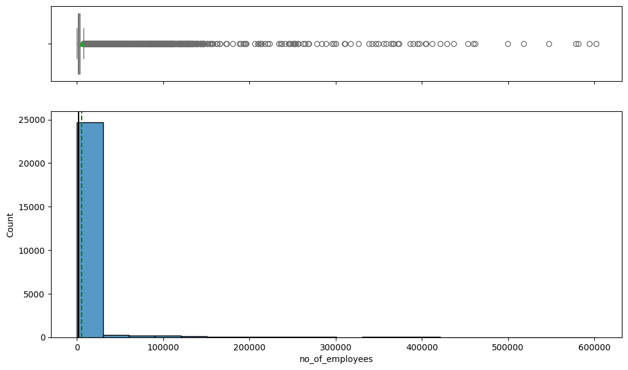

```python
# Plotting the distribution and outliers of number of employees
histogram_boxplot(visa_df, 'no_of_employees', bins = 20)
```

**`Observations:`**

- The no_of_employees variable is highly right skewed, with most companies having a relatively small number of employees.
- The histogram shows that the majority of observations are concentrated near the lower employee count range.
- The boxplot shows several extreme values on the higher side, indicating the presence of large companies with very high employee counts.
- The mean is greater than the median, which confirms the right skewed nature of the distribution.
- Since this feature contains extreme values, outlier treatment or transformation can be considered before model building depending on the model requirements.

#### **Histogram & Boxplot of 'yr_of_estab'**

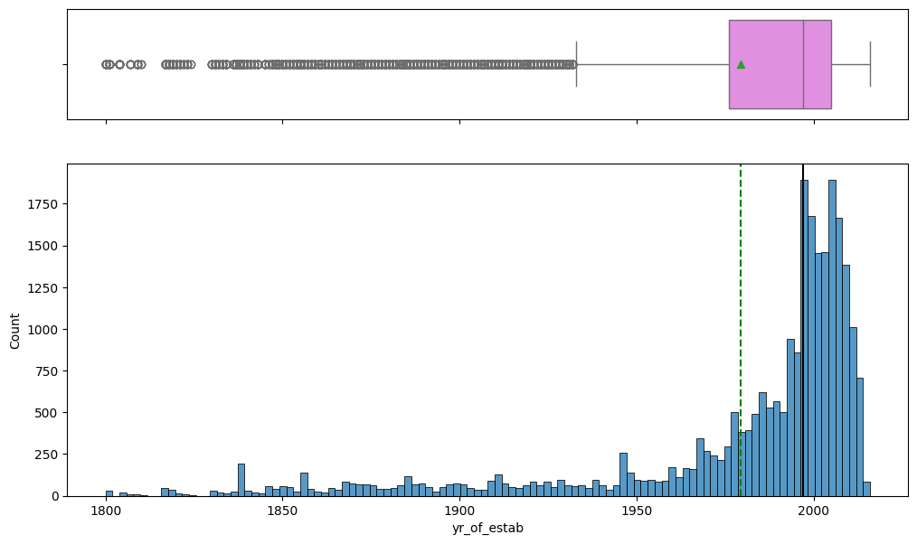

```python
# Plotting the distribution and outliers of company establishment year
histogram_boxplot(visa_df, 'yr_of_estab')
```

**`Observations:`**

- The yr_of_estab variable is left skewed, with most companies established in recent decades.
- A large number of companies were established between the late 1980s and early 2010s, especially around the 1990s and 2000s.
- The boxplot shows several lower end outliers, representing very old companies established much earlier than the majority of employers.
- The median establishment year appears to be around the late 1990s, while the mean is pulled lower because of older companies in the dataset.
- The presence of older companies is not necessarily an error, so these values should be treated carefully and not removed without business justification.

#### **Histogram of prevailing_wage by unit_of_wage**

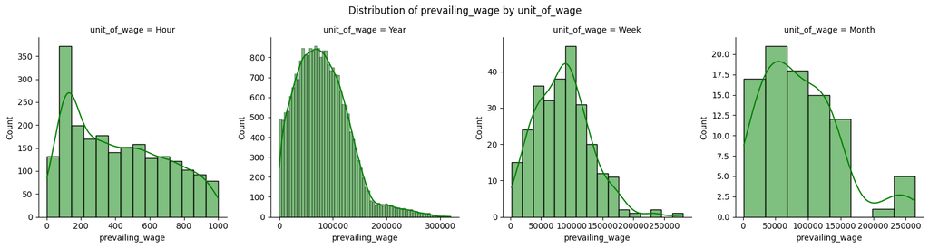

```python
# Plotting prevailing wage distribution separately for each unit of wage
g = sns.FacetGrid(visa_df, col = 'unit_of_wage', col_wrap = 4, height = 4, sharex = False, sharey = False)
g.map_dataframe(sns.histplot, x = 'prevailing_wage', kde = True, color = 'Green')
g.fig.suptitle('Distribution of prevailing_wage by unit_of_wage', y = 1.05)
plt.show()
```

**`Observations:`**

- The distribution of prevailing_wage differs significantly across different wage units, so it should be analyzed separately for Hour, Year, Week, and Month.
- For the Hourly wage unit, most values are concentrated below 1,000, with a right skewed distribution. This indicates that hourly wages are recorded on a much smaller scale compared with other wage units.
- For the Yearly wage unit, the distribution is much wider and most observations are concentrated around the lower to middle wage range, with a long right tail extending beyond 300,000.
- For the Weekly wage unit, most values are concentrated between approximately 50,000 and 150,000, with a few higher wage values creating a slight right skew.
- For the Monthly wage unit, the distribution has fewer observations compared with the other wage units and shows some high wage values above 200,000.
- Overall, prevailing_wage should not be interpreted directly without considering unit_of_wage, because each wage unit is measured on a different scale.

#### **Boxplot of prevailing_wage by unit_of_wage**

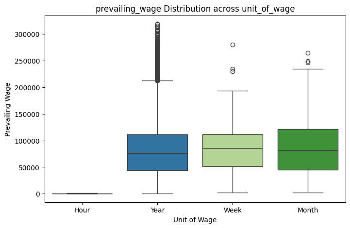

```python
# Comparing prevailing wage distribution across different wage units
plt.figure(figsize=(8, 5))
sns.boxplot(data=visa_df, x='unit_of_wage', y='prevailing_wage', palette = 'Paired')
plt.title('prevailing_wage Distribution across unit_of_wage')
plt.xlabel('Unit of Wage')
plt.ylabel('Prevailing Wage')
plt.show()
```

**`Observations:`**

- The boxplot confirms that prevailing_wage varies substantially across different wage units.
- The Hourly wage category has values on a much smaller scale compared with Yearly, Weekly, and Monthly wage categories.
- The Yearly wage category shows a wide spread and contains many high value outliers above the upper whisker, indicating that some annual wages are much higher than the typical range.
- The Weekly and Monthly wage categories also show large variation, but they have fewer visible outliers compared with the Yearly wage category.
- The median wages for Yearly, Weekly, and Monthly units appear relatively closer to each other on the plot, while Hourly wages remain compressed near the bottom due to scale differences.
- This reinforces that prevailing_wage should be interpreted along with unit_of_wage rather than as a standalone numerical variable.